# Html_Spotify_Premium_Family

## Load data

```python
import pandas as pd
import numpy as np

# Load the dataframes from csv files
df = pd.read_csv("https://storage.googleapis.com/datalynn-datasets/interview-challenge/entertainment-and-media/Spotify_Premium_Family/df.csv")
```

## **Question 1:**

"Spotify recently launched an update to the Family Mix playlist feature. You're given a dataset named `FamilyData`. Conduct an exploratory analysis on the `family_mix_usage` column to understand the impact of the recent update. What insights can you derive from the data regarding the usage of the Family Mix playlist after the update?"

**Problem Solving Ideas and Tips:**

- Start by visualizing the distribution of the `family_mix_usage` to understand the average monthly plays.
- Calculate summary statistics to get a sense of central tendency and spread.
- A before-and-after comparison would be ideal, but since we have data from after the update, we can at least infer if many families are making good use of the Family Mix feature.
- Outliers in the data may indicate families that are particularly engaged or disengaged with the feature.

**Code Solution:**

```
Summary Statistics:
 count    1000.000000
mean      253.458000
std       141.783874
min        10.000000
25%       132.000000
50%       255.500000
75%       372.000000
max       499.000000
Name: family_mix_usage, dtype: float64
```

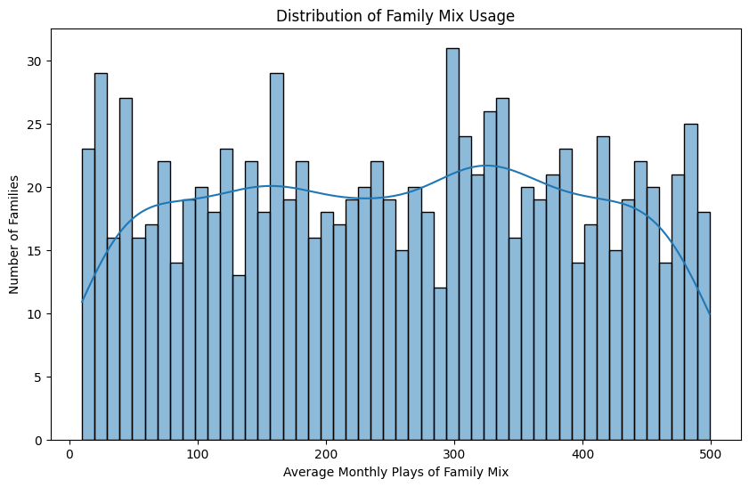

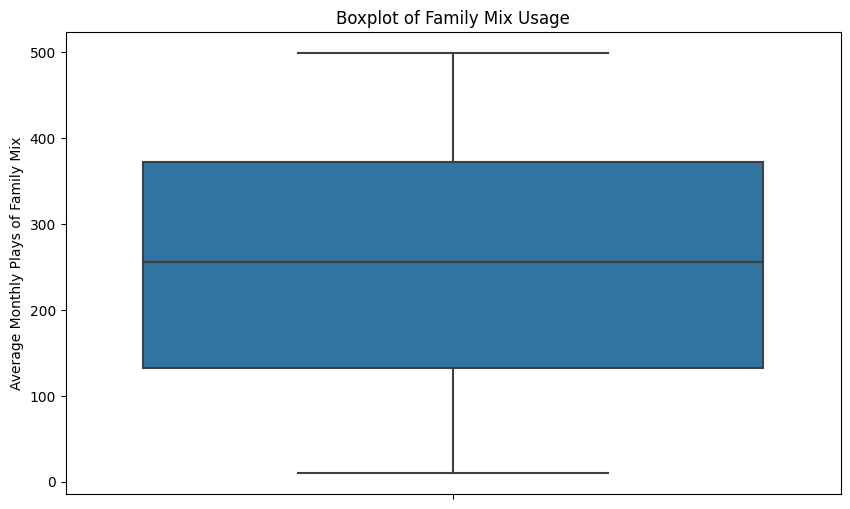

```python
import pandas as pd
import matplotlib.pyplot as plt
import seaborn as sns

# Assuming df is the dataset loaded
# df = pd.read_csv('FamilyData.csv') # Uncomment this if you're reading data from a CSV file.

# Summary statistics
summary_stats = df['family_mix_usage'].describe()
print("Summary Statistics:\n", summary_stats)

# Visualization
plt.figure(figsize=(10,6))
sns.histplot(df['family_mix_usage'], bins=50, kde=True)
plt.title("Distribution of Family Mix Usage")
plt.xlabel("Average Monthly Plays of Family Mix")
plt.ylabel("Number of Families")
plt.show()

# Checking for outliers using a boxplot
plt.figure(figsize=(10,6))
sns.boxplot(y=df['family_mix_usage'])
plt.title("Boxplot of Family Mix Usage")
plt.ylabel("Average Monthly Plays of Family Mix")
plt.show()
```

**Derived Insights:**

1. By examining the summary statistics, you can understand the average, median, and range of monthly plays for the Family Mix feature.
2. The histogram provides a visual representation of the distribution. A peak towards the higher end would indicate that many families are actively using the Family Mix playlist after the update.
3. Outliers in the boxplot may suggest families that are exceptionally engaged (or not) with the feature. If there are many high outliers, it could indicate that the new feature is well-received by a subset of users.
4. Conversely, if there are many families not using the feature at all (values close to 0), it might suggest that some users are not aware of or are not interested in the update.

## **Question 2:**

Spotify is curious about the relationship between the length of time families have been subscribed (`active_months`) and their likelihood to churn (`churned_last_month`). Using the `FamilyData` dataset, create a model to predict the likelihood of churn based on the number of active months. Clearly state which feature is the target variable and its type.

**Problem Solving Ideas and Tips:**

- The target variable is `churned_last_month`, which is binary. Therefore, we're looking at a binary classification problem.
- A Logistic Regression is a good starting point for this kind of problem because of its simplicity and interpretability.
- We should visualize the data to understand the distribution of churn across different months of activity.
- It's essential to split the dataset into training and testing sets to evaluate the model's performance.

**Code Solution:**

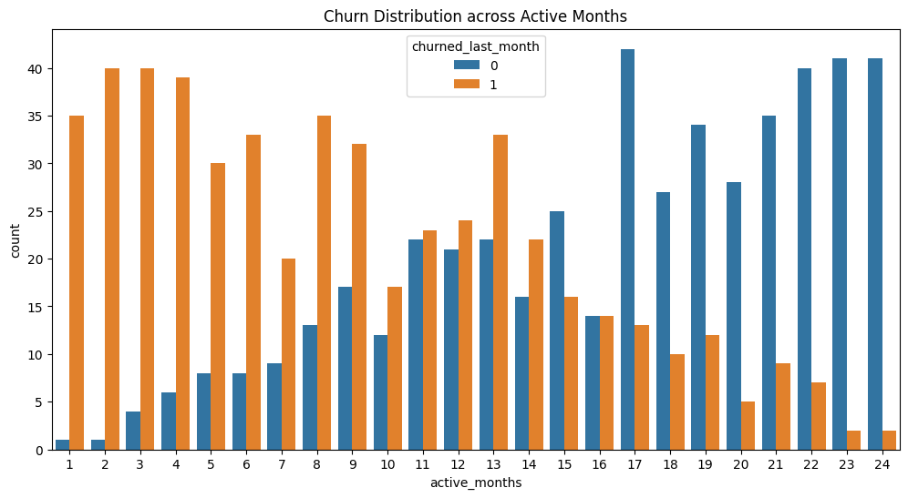

```
Classification Report:
               precision    recall  f1-score   support

           0       0.71      0.77      0.74       146
           1       0.77      0.70      0.73       154

    accuracy                           0.74       300
   macro avg       0.74      0.74      0.74       300
weighted avg       0.74      0.74      0.74       300

Confusion Matrix:
 [[113  33]
 [ 46 108]]
```

```python
import pandas as pd
import numpy as np
import matplotlib.pyplot as plt
from sklearn.model_selection import train_test_split
from sklearn.linear_model import LogisticRegression
from sklearn.metrics import classification_report, confusion_matrix

# Assuming df is the dataset loaded
# df = pd.read_csv('FamilyData.csv') # Uncomment this if you're reading data from a CSV file.

# Visualization to understand the distribution
plt.figure(figsize=(12, 6))
sns.countplot(data=df, x='active_months', hue='churned_last_month')
plt.title("Churn Distribution across Active Months")
plt.show()

# Splitting the data into training and testing sets
X = df[['active_months']]
y = df['churned_last_month']
X_train, X_test, y_train, y_test = train_test_split(X, y, test_size=0.3, random_state=42)

# Creating a Logistic Regression model
model = LogisticRegression()
model.fit(X_train, y_train)

# Predictions
y_pred = model.predict(X_test)

# Performance evaluation
print("Classification Report:\n", classification_report(y_test, y_pred))
print("Confusion Matrix:\n", confusion_matrix(y_test, y_pred))
```

**Derived Insights:**

1. The classification report provides details on precision, recall, f1-score, and support for both churned (1) and not churned (0) classes.
2. The confusion matrix gives a breakdown of true positives, true negatives, false positives, and false negatives.
3. By examining the coefficient of the logistic regression model, you can understand how the likelihood of churn changes as the `active_months` increase.
4. The visualization can give an insight into how churn rates vary across different subscription lengths.

## **Question 3:**

Your team is concerned about the revenue from families based in different regions. From the `FamilyData` dataset, write an SQL query to find the average `monthly_payment` for families from each `family_region`. However, there seems to be an error in the dataset: some families have a monthly payment of 0, which seems erroneous. Adjust your query to exclude these families. Additionally, upon visualizing the average payments in a bar graph, what insights or recommendations would you provide to the business?

**Problem Solving Ideas and Tips:**

1. **Data Filtration**: First and foremost, ensure that the erroneous data (families with a monthly payment of 0) is excluded from our calculations.
2. **Aggregation**: The key here is to aggregate the data by 'family_region' and compute the average 'monthly_payment'.
3. **Visualization**: Visual representations can offer better insights than mere numbers. Plotting a bar graph can clearly show which regions are bringing in more revenue on average.
4. **Insights and Recommendations**: Always relate insights back to the business problem. Recommendations can be based on focusing on high-revenue regions or improving marketing efforts in low-revenue regions.

**Solution:**

```
  family_region  avg_monthly_payment
0       Central            14.653465
1          East            14.885417
2         North            15.243523
3         South            14.906667
4          West            14.893617
```

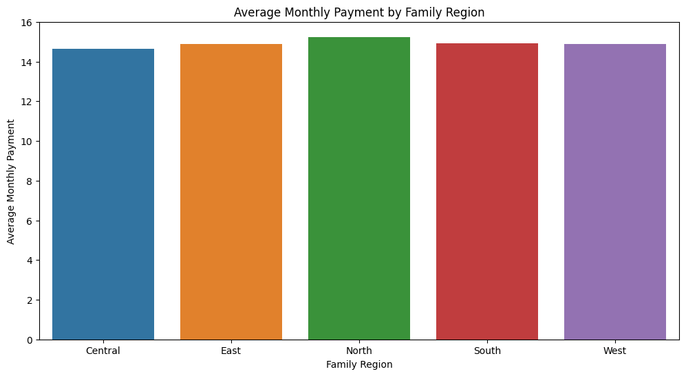

```python
import sqlite3
import pandas as pd
import matplotlib.pyplot as plt
import seaborn as sns

# Convert pandas dataframe to SQL table (Assuming df is the dataframe for FamilyData)
con = sqlite3.connect(":memory:")
df.to_sql("FamilyData", con, index=False)

# SQL Query to get average monthly_payment by family_region excluding families with monthly_payment = 0
query = """
SELECT family_region, AVG(monthly_payment) as avg_monthly_payment
FROM FamilyData
WHERE monthly_payment > 0
GROUP BY family_region
"""

avg_payments = pd.read_sql(query, con)

# Displaying the SQL results
print(avg_payments)

# Visualization using seaborn
plt.figure(figsize=(12, 6))
sns.barplot(data=avg_payments, x='family_region', y='avg_monthly_payment')
plt.title("Average Monthly Payment by Family Region")
plt.ylabel("Average Monthly Payment")
plt.xlabel("Family Region")
plt.show()

# Close the connection
con.close()
```

**Insights and Recommendations**:

1. The regions with the highest average monthly payments can be considered as potential markets for launching any new premium features or targeted marketing.
2. Regions with lower monthly payments might need further investigation. Are these regions economically weaker, or is there strong competition from other streaming services? Strategic decisions can be taken based on these findings.
3. Regions with the lowest average monthly payments can be targeted with special promotions or discounts to improve retention and increase revenue.